# SHRS Education Analysis — 2020 Entry Requirements & Training (Table 5.4)

SHRS MQE Capstone Team

2026-02-13

```r
library(tidyverse)
library(scales)
library(knitr)
library(kableExtra)
```

# 0 — Configuration

```r
VINTAGE <- 2020

CSV_PATH <- file.path(path.expand("~"), "Documents", "SHRS_Analysis",
                       "market_analysis", "v3data", "projections_csv",
                       "education_csv", as.character(VINTAGE),
                       paste0("education_", VINTAGE, " - Table 5.4.csv"))

soc_xwalk <- tribble(
  ~shrs_program, ~shrs_dept, ~soc_code,
  "SLP", "CSD", "29-1127",
  "AuD", "CSD", "29-1181",
  "HIM", "HIM", "29-9021",
  "OTD", "RST", "29-1122",
  "DPT", "RST", "29-1123",
  "PAS", "PAS", "29-1071",
  "AT",  "SMN", "29-9091",
  "DN",  "SMN", "29-1031",
  "SS",  "SMN", "29-1128"
)

target_socs <- soc_xwalk$soc_code
signal_colors <- c("Green" = "#27ae60", "Yellow" = "#f39c12", "Red" = "#e74c3c")
```

# 1 — Load & Clean

The 2020 vintage has a merged header (“title and code” in column 1) but data rows follow the standard layout. Also note: **AT was classified as Bachelor’s degree entry** in this vintage — it was reclassified to Master’s starting 2021.

```r
raw <- read_csv(CSV_PATH, show_col_types = FALSE)

names(raw)[1] <- "occ_title"
names(raw)[2] <- "soc_code"
names(raw)[3] <- "entry_education"
names(raw)[4] <- "work_experience"
names(raw)[5] <- "ojt_required"

if (ncol(raw) >= 6) raw <- raw |> select(1:5)

raw <- raw |>
  mutate(
    soc_code  = str_trim(soc_code),
    occ_title = str_remove_all(occ_title, "\\(\\d+\\)|\\[\\d+\\]") |> str_trim()
  )

shrs_t54 <- raw |>
  filter(soc_code %in% target_socs) |>
  left_join(soc_xwalk, by = "soc_code")
```

```r
cat(paste0("**Vintage:** ", VINTAGE, " | **Programs found:** ", nrow(shrs_t54), " of 9\n\n"))
```

**Vintage:** 2020 | **Programs found:** 8 of 9

```r
missing <- setdiff(target_socs, shrs_t54$soc_code)
if (length(missing) > 0) {
  miss_names <- soc_xwalk |> filter(soc_code %in% missing) |> pull(shrs_program)
  cat(paste0("> <span style='color:#e74c3c;'>**Missing:**</span> ",
             paste(miss_names, collapse = ", "),
             " — not separately reported until a later vintage.\n\n"))
}
```

> **Missing:** HIM — not separately reported until a later vintage.

```r
# Flag AT reclassification
at_row <- shrs_t54 |> filter(soc_code == "29-9091")
if (nrow(at_row) > 0 && at_row$entry_education == "Bachelor's degree") {
  cat(paste0("> <span style='color:#f39c12;'>**Reclassification note:**</span> ",
             "Athletic Trainers (AT) is listed as **Bachelor's degree** entry in ",
             "this vintage. BLS reclassified AT to **Master's degree** starting ",
             "in the 2021 vintage, reflecting the CAATE degree-level mandate.\n\n"))
}
```

> **Reclassification note:** Athletic Trainers (AT) is listed as **Bachelor’s degree** entry in this vintage. BLS reclassified AT to **Master’s degree** starting in the 2021 vintage, reflecting the CAATE degree-level mandate.

# 2 — Entry Requirements

```r
shrs_t54 |>
  select(Program = shrs_program, Dept = shrs_dept,
         `Entry Education` = entry_education,
         `Work Experience` = work_experience,
         `OJT Required` = ojt_required) |>
  arrange(factor(Program, levels = soc_xwalk$shrs_program)) |>
  kable(caption = paste0("BLS Entry Requirements (", VINTAGE, ")")) |>
  kable_styling(bootstrap_options = c("striped", "hover"), full_width = FALSE)
```

BLS Entry Requirements (2020)

| Program | Dept | Entry Education | Work Experience | OJT Required |
| --- | --- | --- | --- | --- |
| SLP | CSD | Master’s degree | None | Internship/residency |
| AuD | CSD | Doctoral or professional degree | None | None |
| OTD | RST | Master’s degree | None | None |
| DPT | RST | Doctoral or professional degree | None | None |
| PAS | PAS | Master’s degree | None | None |
| AT | SMN | Bachelor’s degree | None | None |
| DN | SMN | Bachelor’s degree | None | Internship/residency |
| SS | SMN | Bachelor’s degree | None | None |

# 3 — Training Burden & Scorecard

```r
shrs_t54 <- shrs_t54 |>
  mutate(
    edu_tier = case_when(
      entry_education == "Doctoral or professional degree" ~ 4,
      entry_education == "Master's degree" ~ 3,
      entry_education == "Bachelor's degree" ~ 2,
      entry_education == "Associate's degree" ~ 1, TRUE ~ 0
    ),
    tier_label = case_when(
      edu_tier == 4 ~ "Doctoral", edu_tier == 3 ~ "Master's",
      edu_tier == 2 ~ "Bachelor's", edu_tier == 1 ~ "Associate's",
      TRUE ~ "Below Associate's"
    ),
    edu_years = case_when(
      entry_education == "Doctoral or professional degree" ~ 21,
      entry_education == "Master's degree" ~ 18,
      entry_education == "Bachelor's degree" ~ 16,
      entry_education == "Associate's degree" ~ 14, TRUE ~ 12
    ),
    edu_burden = case_when(
      entry_education == "Doctoral or professional degree" ~ 3,
      entry_education == "Master's degree" ~ 2,
      entry_education == "Bachelor's degree" ~ 1,
      entry_education == "Associate's degree" ~ 0, TRUE ~ 0
    ),
    exp_burden = case_when(
      work_experience == "5 years or more" ~ 3,
      work_experience == "Less than 5 years" ~ 2,
      work_experience == "None" ~ 0, TRUE ~ 0
    ),
    ojt_burden = case_when(
      str_detect(ojt_required, regex("long-term", ignore_case = TRUE)) ~ 3,
      str_detect(ojt_required, regex("moderate", ignore_case = TRUE)) ~ 2,
      str_detect(ojt_required, regex("internship|residency", ignore_case = TRUE)) ~ 2,
      str_detect(ojt_required, regex("short-term", ignore_case = TRUE)) ~ 1,
      ojt_required == "None" ~ 0, TRUE ~ 0
    ),
    total_burden = edu_burden + exp_burden + ojt_burden,
    d1_training_simple = round((1 - total_burden / 9) * 100, 1),
    d2_exp_accessible  = round((1 - exp_burden / 3) * 100, 1),
    composite = round((d1_training_simple + d2_exp_accessible) / 2, 1),
    signal = case_when(composite >= 70 ~ "Green", composite >= 50 ~ "Yellow", TRUE ~ "Red")
  )

shrs_t54 |>
  select(Program = shrs_program, `Entry Ed` = entry_education,
         `Edu` = edu_burden, `Exp` = exp_burden, `OJT` = ojt_burden,
         `Total (0-9)` = total_burden,
         `Train Simple` = d1_training_simple, `Exp Access` = d2_exp_accessible,
         Composite = composite, Signal = signal) |>
  arrange(factor(Program, levels = soc_xwalk$shrs_program)) |>
  kable(digits = 1, caption = paste0("Training Burden & Scorecard (", VINTAGE, ")")) |>
  kable_styling(bootstrap_options = c("striped", "hover"), full_width = FALSE)
```

Training Burden & Scorecard (2020)

| Program | Entry Ed | Edu | Exp | OJT | Total (0-9) | Train Simple | Exp Access | Composite | Signal |
| --- | --- | --- | --- | --- | --- | --- | --- | --- | --- |
| SLP | Master’s degree | 2 | 0 | 2 | 4 | 55.6 | 100 | 77.8 | Green |
| AuD | Doctoral or professional degree | 3 | 0 | 0 | 3 | 66.7 | 100 | 83.3 | Green |
| OTD | Master’s degree | 2 | 0 | 0 | 2 | 77.8 | 100 | 88.9 | Green |
| DPT | Doctoral or professional degree | 3 | 0 | 0 | 3 | 66.7 | 100 | 83.3 | Green |
| PAS | Master’s degree | 2 | 0 | 0 | 2 | 77.8 | 100 | 88.9 | Green |
| AT | Bachelor’s degree | 1 | 0 | 0 | 1 | 88.9 | 100 | 94.4 | Green |
| DN | Bachelor’s degree | 1 | 0 | 2 | 3 | 66.7 | 100 | 83.3 | Green |
| SS | Bachelor’s degree | 1 | 0 | 0 | 1 | 88.9 | 100 | 94.4 | Green |

[figure not shown]

```r
shrs_t54 |>
  ggplot(aes(x = factor(shrs_program,
                         levels = intersect(soc_xwalk$shrs_program,
                                            shrs_t54$shrs_program)),
             y = edu_years, fill = tier_label)) +
  geom_col(width = 0.6) +
  geom_text(aes(label = tier_label), vjust = -0.3, size = 3.5) +
  scale_fill_manual(values = c("Doctoral" = "#2c3e50", "Master's" = "#2c7bb6",
                                "Bachelor's" = "#27ae60", "Associate's" = "#f39c12"),
                    name = "Tier") +
  scale_y_continuous(limits = c(0, 24)) +
  labs(title = paste0("Entry Education by Program (", VINTAGE, ")"),
       subtitle = "Note: AT classified as Bachelor's in this vintage (reclassified to Master's in 2021)",
       x = NULL, y = "Years of Education") +
  theme_minimal(base_size = 13) +
  theme(axis.text.x = element_text(angle = 30, hjust = 1), legend.position = "bottom")
```

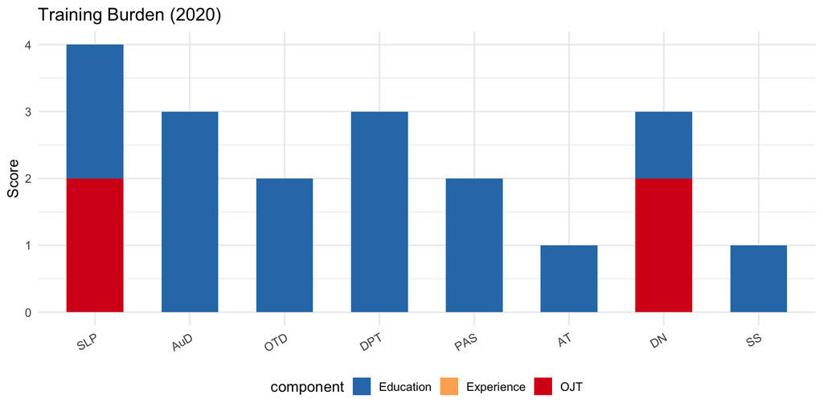

```r
shrs_t54 |>
  select(shrs_program, edu_burden, exp_burden, ojt_burden) |>
  pivot_longer(-shrs_program, names_to = "component", values_to = "score") |>
  mutate(component = case_when(
    component == "edu_burden" ~ "Education", component == "exp_burden" ~ "Experience",
    component == "ojt_burden" ~ "OJT")) |>
  ggplot(aes(x = factor(shrs_program,
                         levels = intersect(soc_xwalk$shrs_program,
                                            shrs_t54$shrs_program)),
             y = score, fill = component)) +
  geom_col(width = 0.6) +
  scale_fill_manual(values = c("Education" = "#2c7bb6", "Experience" = "#fdae61", "OJT" = "#d7191c")) +
  labs(title = paste0("Training Burden (", VINTAGE, ")"), x = NULL, y = "Score") +
  theme_minimal(base_size = 13) +
  theme(axis.text.x = element_text(angle = 30, hjust = 1), legend.position = "bottom")
```

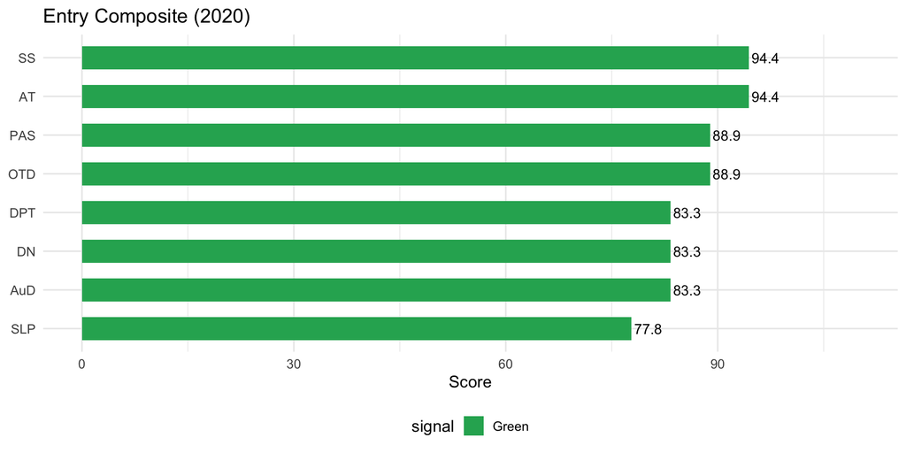

```r
shrs_t54 |>
  ggplot(aes(x = reorder(shrs_program, composite), y = composite, fill = signal)) +
  geom_col(width = 0.6) + geom_text(aes(label = composite), hjust = -0.1, size = 4) +
  coord_flip() + scale_fill_manual(values = signal_colors) +
  scale_y_continuous(limits = c(0, 110)) +
  labs(title = paste0("Entry Composite (", VINTAGE, ")"), x = NULL, y = "Score") +
  theme_minimal(base_size = 13) + theme(legend.position = "bottom")
```

# 4 — Reclassification Tracker

Compare 2020 entry requirements against later vintages to document BLS changes.

```r
# Check for 2021 T5.4 to compare
T54_2021_PATH <- file.path(path.expand("~"), "Documents", "SHRS_Analysis",
                            "market_analysis", "v3data", "projections_csv",
                            "education_csv", "2021",
                            "education_2021 - Table 5.4.csv")

if (file.exists(T54_2021_PATH)) {
  raw_2021 <- read_csv(T54_2021_PATH, show_col_types = FALSE)
  names(raw_2021)[1] <- "occ_title"
  names(raw_2021)[2] <- "soc_code"
  names(raw_2021)[3] <- "entry_education"

  cmp <- shrs_t54 |>
    select(shrs_program, soc_code, entry_2020 = entry_education) |>
    left_join(
      raw_2021 |>
        mutate(soc_code = str_trim(soc_code)) |>
        filter(soc_code %in% target_socs) |>
        select(soc_code, entry_2021 = entry_education),
      by = "soc_code"
    ) |>
    mutate(changed = entry_2020 != entry_2021)

  changes <- cmp |> filter(changed)
  if (nrow(changes) > 0) {
    cat("**BLS Reclassifications (2020 to 2021):**\n\n")
    for (j in seq_len(nrow(changes))) {
      r <- changes[j, ]
      cat(paste0("- <span style='color:#f39c12;'>**", r$shrs_program,
                 "**</span>: ", r$entry_2020, " → ", r$entry_2021, "\n"))
    }
  } else {
    cat("No entry-level reclassifications between 2020 and 2021.\n")
  }

  t54_reclass_2020_2021 <- cmp
} else {
  cat("*2021 Table 5.4 not found — skipping reclassification check.*\n")
}
```

**BLS Reclassifications (2020 to 2021):**

- **AT**: Bachelor’s degree → Master’s degree

# 5 — Stored Outputs

```r
t54_2020_data      <- shrs_t54
t54_2020_scorecard <- shrs_t54 |>
  select(shrs_program, shrs_dept, soc_code, entry_education,
         work_experience, ojt_required, edu_tier, tier_label, edu_years,
         edu_burden, exp_burden, ojt_burden, total_burden,
         d1_training_simple, d2_exp_accessible, composite, signal)
```

```r
cat("| Variable | Description | Dims |\n|---|---|---|\n")
```

| Variable | Description | Dims |
| --- | --- | --- |

```r
cat(paste0("| `t54_2020_data` | Full T5.4 data | ", nrow(t54_2020_data), " x ", ncol(t54_2020_data), " |\n"))
```

`t54_2020_data` | Full T5.4 data | 8 x 18 |

```r
cat(paste0("| `t54_2020_scorecard` | Entry scorecard | ", nrow(t54_2020_scorecard), " x ", ncol(t54_2020_scorecard), " |\n"))
```

`t54_2020_scorecard` | Entry scorecard | 8 x 17 |

```r
if (exists("t54_reclass_2020_2021")) {
  cat(paste0("| `t54_reclass_2020_2021` | 2020 vs 2021 reclassification tracker | ",
             nrow(t54_reclass_2020_2021), " x ", ncol(t54_reclass_2020_2021), " |\n"))
}
```

`t54_reclass_2020_2021` | 2020 vs 2021 reclassification tracker | 8 x 5 |

**Source:** BLS Table 5.4, 2020 vintage.

**Key finding:** AT reclassified from Bachelor’s (2020) to Master’s (2021), reflecting CAATE mandate. HIM (29-9021) not present in 2020 T5.4 — added in 2021.